# Food Security Questions

### Vanguard graphs

Vanguard Survey – Food Security Questions  
“The next set of questions will ask you about food in your household.  
**How often…”**

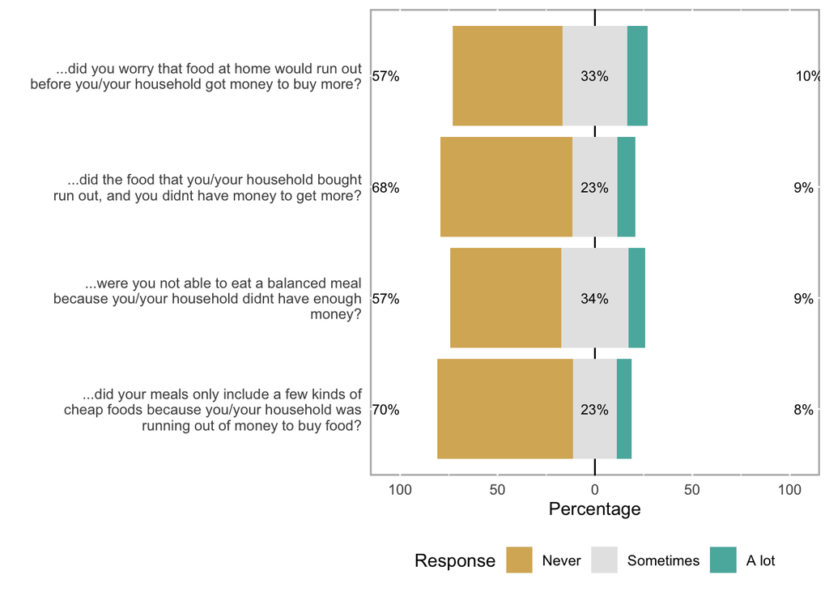

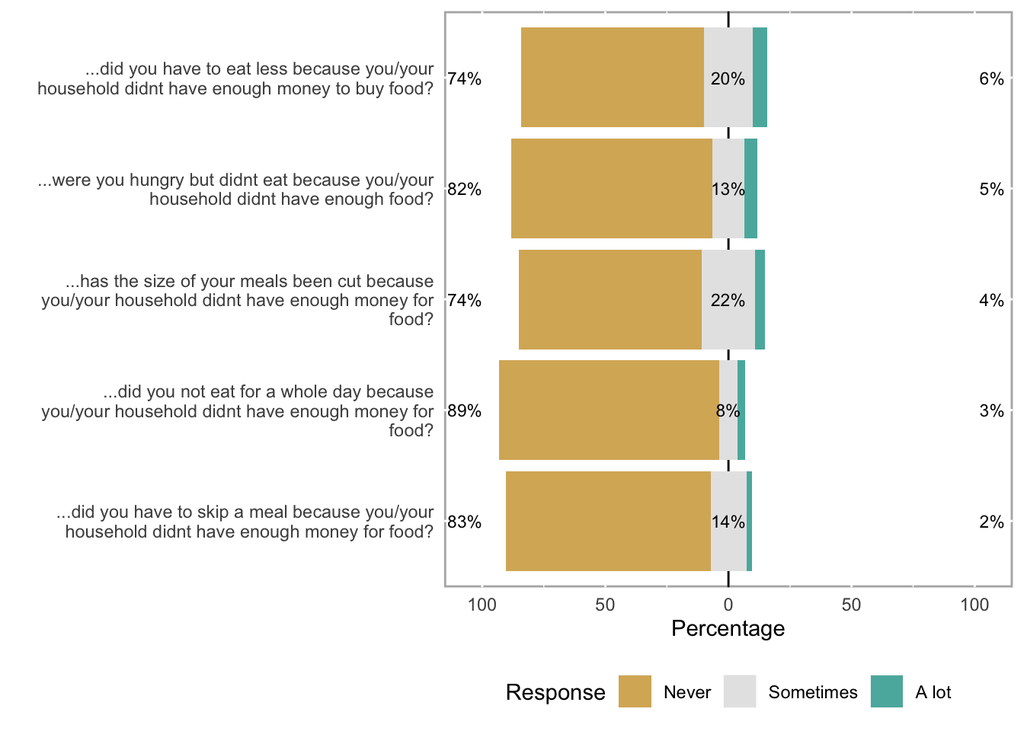

Vanguard Survey – Food Security Questions, by Youth Arm variable  
“The next set of questions will ask you about food in your household.  
**How often…”**

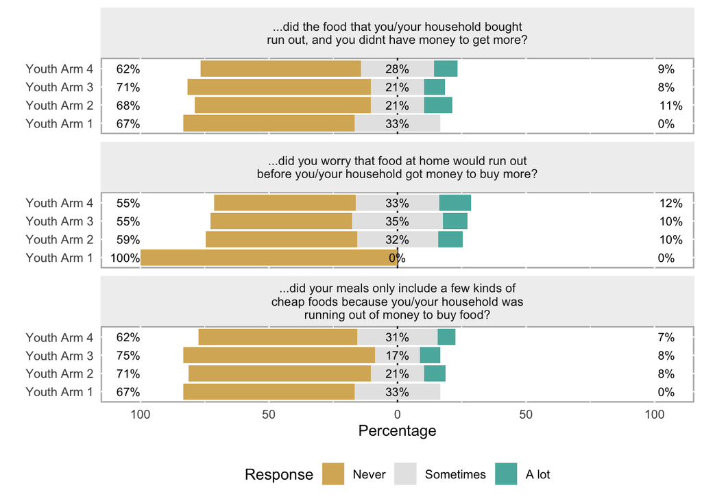

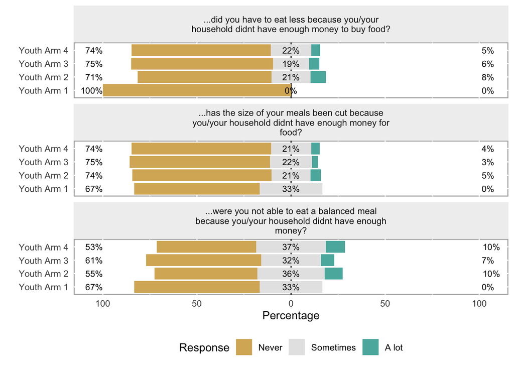

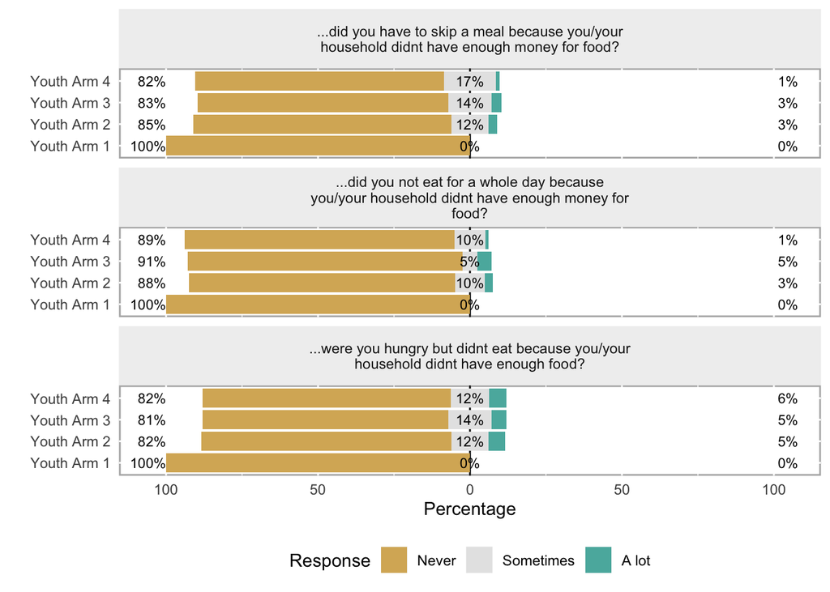

### Vanguard Tables

“The next set of questions will ask you about food in your household.  
How often…”

**“…did you worry that food at home would run out before you/your household got money to buy more?”**

| arm | NA_ | Prefer not to answer | Never | Sometimes | A lot | Total |
| --- | --- | --- | --- | --- | --- | --- |
| Youth Arm 1 | 0 (75.0%) | 3 (6.2%) | 1 (18.8%) | 0 (0.0%) | 12 (0.0%) | 16 (100.0%) |
| Youth Arm 2 | 7 (82.9%) | 43 (0.2%) | 1 (9.9%) | 23 (5.3%) | 360 (1.6%) | 434 (100.0%) |
| Youth Arm 3 | 12 (74.9%) | 69 (0.8%) | 4 (13.4%) | 44 (8.6%) | 385 (2.3%) | 514 (100.0%) |
| Youth Arm 4 | 11 (83.7%) | 49 (0.5%) | 3 (8.7%) | 29 (5.1%) | 472 (2.0%) | 564 (100.0%) |
| Total | 30 (80.4%) | 164 (0.6%) | 9 (10.7%) | 96 (6.3%) | 1229 (2.0%) | 1528 (100.0%) |

**“…did the food that you/your household bought run out, and you didnt have money to get more?”**

| arm | NA_ | Prefer not to answer | Never | Sometimes | A lot | Total |
| --- | --- | --- | --- | --- | --- | --- |
| Youth Arm 1 | 0 (75.0%) | 2 (6.2%) | 1 (12.5%) | 1 (6.2%) | 12 (0.0%) | 16 (100.0%) |
| Youth Arm 2 | 8 (82.9%) | 50 (0.2%) | 1 (11.5%) | 15 (3.5%) | 360 (1.8%) | 434 (100.0%) |
| Youth Arm 3 | 10 (74.9%) | 89 (0.8%) | 4 (17.3%) | 26 (5.1%) | 385 (1.9%) | 514 (100.0%) |
| Youth Arm 4 | 8 (83.7%) | 55 (0.7%) | 4 (9.8%) | 25 (4.4%) | 472 (1.4%) | 564 (100.0%) |
| Total | 26 (80.4%) | 196 (0.7%) | 10 (12.8%) | 67 (4.4%) | 1229 (1.7%) | 1528 (100.0%) |

**“…did your meals only include a few kinds of cheap foods because you/your household was running out of money to buy food?”**

| arm | NA_ | Prefer not to answer | Never | Sometimes | A lot | Total |
| --- | --- | --- | --- | --- | --- | --- |
| Youth Arm 1 | 0 (75.0%) | 2 (6.2%) | 1 (12.5%) | 1 (6.2%) | 12 (0.0%) | 16 (100.0%) |
| Youth Arm 2 | 6 (82.9%) | 51 (0.5%) | 2 (11.8%) | 15 (3.5%) | 360 (1.4%) | 434 (100.0%) |
| Youth Arm 3 | 10 (74.9%) | 94 (0.6%) | 3 (18.3%) | 22 (4.3%) | 385 (1.9%) | 514 (100.0%) |
| Youth Arm 4 | 6 (83.7%) | 55 (0.5%) | 3 (9.8%) | 28 (5.0%) | 472 (1.1%) | 564 (100.0%) |
| Total | 22 (80.4%) | 202 (0.6%) | 9 (13.2%) | 66 (4.3%) | 1229 (1.4%) | 1528 (100.0%) |

**“…were you not able to eat a balanced meal because you/your household didnt have enough money?”**

| arm | NA_ | Prefer not to answer | Never | Sometimes | A lot | Total |
| --- | --- | --- | --- | --- | --- | --- |
| Youth Arm 1 | 0 (75.0%) | 2 (6.2%) | 1 (12.5%) | 1 (6.2%) | 12 (0.0%) | 16 (100.0%) |
| Youth Arm 2 | 7 (82.9%) | 40 (0.2%) | 1 (9.2%) | 26 (6.0%) | 360 (1.6%) | 434 (100.0%) |
| Youth Arm 3 | 9 (74.9%) | 77 (0.6%) | 3 (15.0%) | 40 (7.8%) | 385 (1.8%) | 514 (100.0%) |
| Youth Arm 4 | 9 (83.7%) | 47 (0.5%) | 3 (8.3%) | 33 (5.9%) | 472 (1.6%) | 564 (100.0%) |
| Total | 25 (80.4%) | 166 (0.5%) | 8 (10.9%) | 100 (6.5%) | 1229 (1.6%) | 1528 (100.0%) |

**“…did you have to eat less because you/your household didnt have enough money to buy food?”**

| arm | NA_ | Prefer not to answer | Never | Sometimes | A lot | Total |
| --- | --- | --- | --- | --- | --- | --- |
| Youth Arm 1 | 0 (75.0%) | 3 (6.2%) | 1 (18.8%) | 0 (0.0%) | 12 (0.0%) | 16 (100.0%) |
| Youth Arm 2 | 6 (82.9%) | 52 (0.2%) | 1 (12.0%) | 15 (3.5%) | 360 (1.4%) | 434 (100.0%) |
| Youth Arm 3 | 7 (74.9%) | 95 (0.6%) | 3 (18.5%) | 24 (4.7%) | 385 (1.4%) | 514 (100.0%) |
| Youth Arm 4 | 4 (83.7%) | 65 (0.7%) | 4 (11.5%) | 19 (3.4%) | 472 (0.7%) | 564 (100.0%) |
| Total | 17 (80.4%) | 215 (0.6%) | 9 (14.1%) | 58 (3.8%) | 1229 (1.1%) | 1528 (100.0%) |

**“…has the size of your meals been cut because you/your household didnt have enough money for food?”**

| arm | NA_ | Prefer not to answer | Never | Sometimes | A lot | Total |
| --- | --- | --- | --- | --- | --- | --- |
| Youth Arm 1 | 0 (75.0%) | 2 (6.2%) | 1 (12.5%) | 1 (6.2%) | 12 (0.0%) | 16 (100.0%) |
| Youth Arm 2 | 4 (82.9%) | 54 (0.2%) | 1 (12.4%) | 15 (3.5%) | 360 (0.9%) | 434 (100.0%) |
| Youth Arm 3 | 4 (74.9%) | 94 (0.6%) | 3 (18.3%) | 28 (5.4%) | 385 (0.8%) | 514 (100.0%) |
| Youth Arm 4 | 4 (83.7%) | 66 (0.5%) | 3 (11.7%) | 19 (3.4%) | 472 (0.7%) | 564 (100.0%) |
| Total | 12 (80.4%) | 216 (0.5%) | 8 (14.1%) | 63 (4.1%) | 1229 (0.8%) | 1528 (100.0%) |

**“…did you have to skip a meal because you/your household didnt have enough money for food?”**

| arm | NA_ | Prefer not to answer | Never | Sometimes | A lot | Total |
| --- | --- | --- | --- | --- | --- | --- |
| Youth Arm 1 | 0 (75.0%) | 3 (6.2%) | 1 (18.8%) | 0 (0.0%) | 12 (0.0%) | 16 (100.0%) |
| Youth Arm 2 | 2 (82.9%) | 62 (0.2%) | 1 (14.3%) | 9 (2.1%) | 360 (0.5%) | 434 (100.0%) |
| Youth Arm 3 | 4 (74.9%) | 104 (0.6%) | 3 (20.2%) | 18 (3.5%) | 385 (0.8%) | 514 (100.0%) |
| Youth Arm 4 | 1 (83.7%) | 72 (0.7%) | 4 (12.8%) | 15 (2.7%) | 472 (0.2%) | 564 (100.0%) |
| Total | 7 (80.4%) | 241 (0.6%) | 9 (15.8%) | 42 (2.7%) | 1229 (0.5%) | 1528 (100.0%) |

**“…were you hungry but didnt eat because you/your household didnt have enough food?”**

| arm | NA_ | Prefer not to answer | Never | Sometimes | A lot | Total |
| --- | --- | --- | --- | --- | --- | --- |
| Youth Arm 1 | 0 (75.0%) | 3 (6.2%) | 1 (18.8%) | 0 (0.0%) | 12 (0.0%) | 16 (100.0%) |
| Youth Arm 2 | 4 (82.9%) | 60 (0.2%) | 1 (13.8%) | 9 (2.1%) | 360 (0.9%) | 434 (100.0%) |
| Youth Arm 3 | 6 (74.9%) | 102 (0.6%) | 3 (19.8%) | 18 (3.5%) | 385 (1.2%) | 514 (100.0%) |
| Youth Arm 4 | 5 (83.7%) | 72 (0.7%) | 4 (12.8%) | 11 (2.0%) | 472 (0.9%) | 564 (100.0%) |
| Total | 15 (80.4%) | 237 (0.6%) | 9 (15.5%) | 38 (2.5%) | 1229 (1.0%) | 1528 (100.0%) |

**“…did you not eat for a whole day because you/your household didnt have enough money for food?”**

| arm | NA_ | Prefer not to answer | Never | Sometimes | A lot | Total |
| --- | --- | --- | --- | --- | --- | --- |
| Youth Arm 1 | 0 (75.0%) | 3 (6.2%) | 1 (18.8%) | 0 (0.0%) | 12 (0.0%) | 16 (100.0%) |
| Youth Arm 2 | 2 (82.9%) | 64 (0.2%) | 1 (14.7%) | 7 (1.6%) | 360 (0.5%) | 434 (100.0%) |
| Youth Arm 3 | 6 (74.9%) | 115 (0.4%) | 2 (22.4%) | 6 (1.2%) | 385 (1.2%) | 514 (100.0%) |
| Youth Arm 4 | 1 (83.7%) | 79 (0.5%) | 3 (14.0%) | 9 (1.6%) | 472 (0.2%) | 564 (100.0%) |
| Total | 9 (80.4%) | 261 (0.5%) | 7 (17.1%) | 22 (1.4%) | 1229 (0.6%) | 1528 (100.0%) |

### G2C graphs

G2C Survey – Food Insecurity Questions  
“The next set of questions will ask you about food in your household.  
**How often…”**

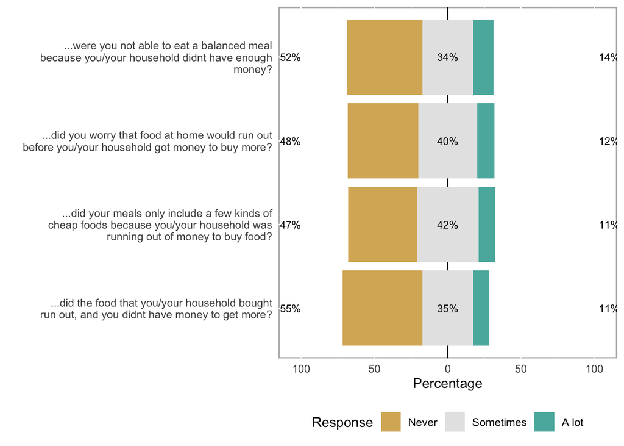

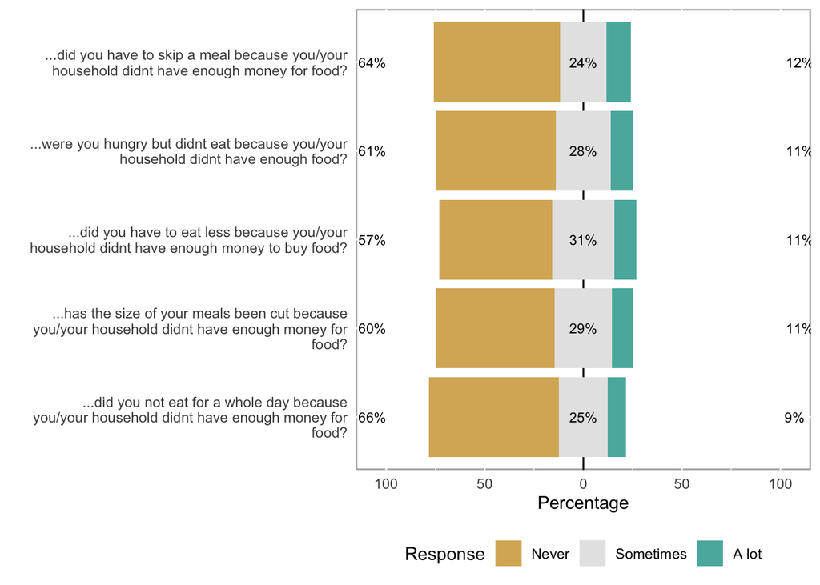

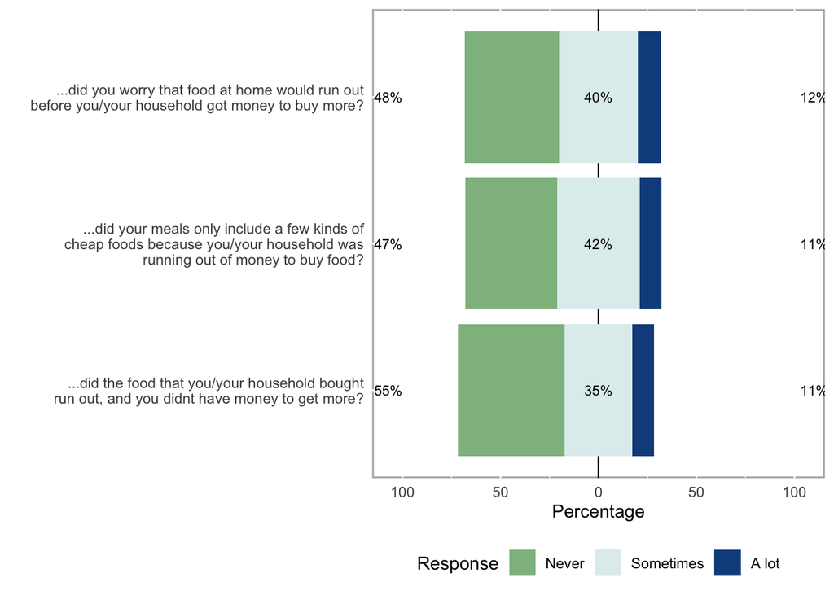

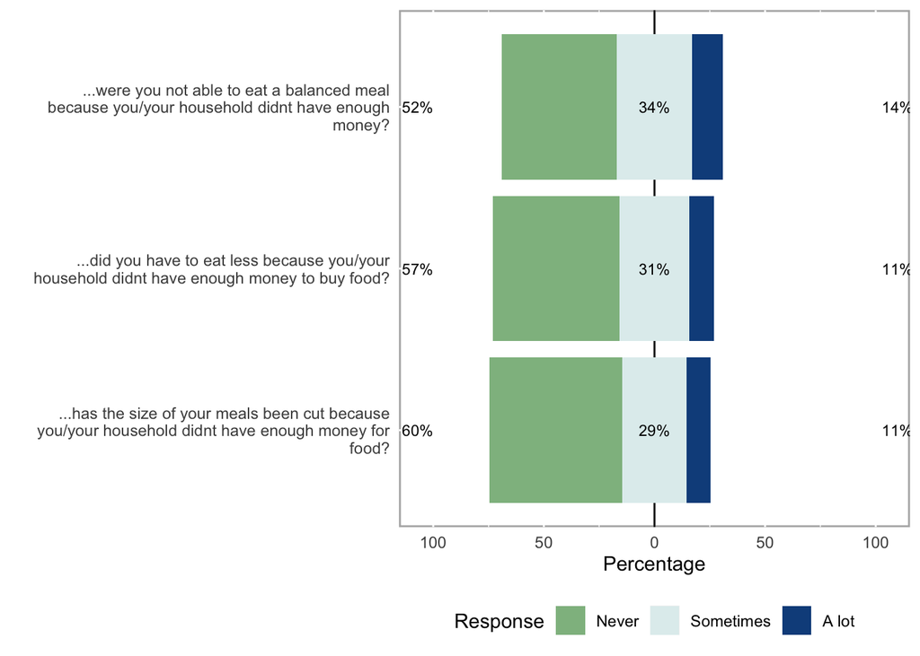

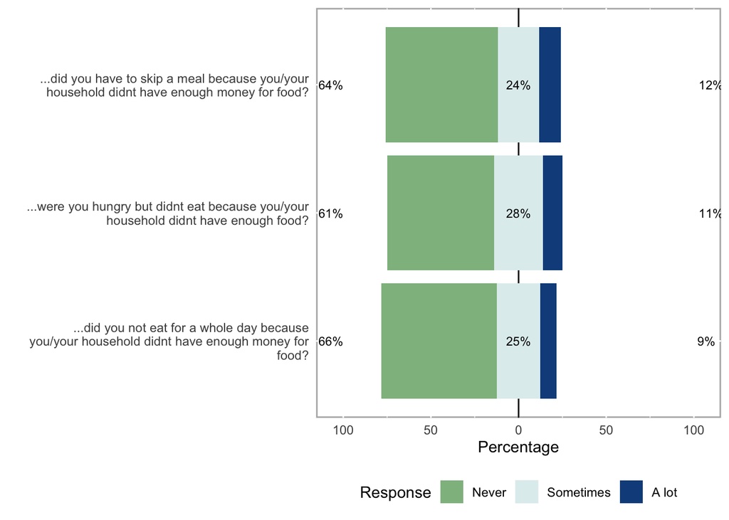

### G2C Tables

“The next set of questions will ask you about food in your household.  
How often…”

**“…did you worry that food at home would run out before you/your household got money to buy more?”**

| cycle1 | Prefer not to answer | Never | Sometimes | A lot | Total |
| --- | --- | --- | --- | --- | --- |
| Cycle 2 | 4 (0.0%) | 10 (55.6%) | 0 (22.2%) | 4 (22.2%) | 18 (100.0%) |
| Cycle 3 | 4 (3.9%) | 24 (47.1%) | 2 (41.2%) | 21 (7.8%) | 51 (100.0%) |
| Undetermined | 5 (4.4%) | 19 (42.2%) | 2 (42.2%) | 19 (11.1%) | 45 (100.0%) |
| Total | 13 (3.5%) | 53 (46.5%) | 4 (38.6%) | 44 (11.4%) | 114 (100.0%) |

**“…did the food that you/your household bought run out, and you didnt have money to get more?”**

| cycle1 | Prefer not to answer | Never | Sometimes | A lot | Total |
| --- | --- | --- | --- | --- | --- |
| Cycle 2 | 4 (0.0%) | 11 (61.1%) | 0 (16.7%) | 3 (22.2%) | 18 (100.0%) |
| Cycle 3 | 4 (3.9%) | 28 (54.9%) | 2 (33.3%) | 17 (7.8%) | 51 (100.0%) |
| Undetermined | 4 (4.4%) | 21 (46.7%) | 2 (40.0%) | 18 (8.9%) | 45 (100.0%) |
| Total | 12 (3.5%) | 60 (52.6%) | 4 (33.3%) | 38 (10.5%) | 114 (100.0%) |

**“…did your meals only include a few kinds of cheap foods because you/your household was running out of money to buy food?”**

| cycle1 | Prefer not to answer | Never | Sometimes | A lot | Total |
| --- | --- | --- | --- | --- | --- |
| Cycle 2 | 3 (0.0%) | 10 (55.6%) | 0 (27.8%) | 5 (16.7%) | 18 (100.0%) |
| Cycle 3 | 4 (3.9%) | 25 (49.0%) | 2 (39.2%) | 20 (7.8%) | 51 (100.0%) |
| Undetermined | 5 (6.7%) | 16 (35.6%) | 3 (46.7%) | 21 (11.1%) | 45 (100.0%) |
| Total | 12 (4.4%) | 51 (44.7%) | 5 (40.4%) | 46 (10.5%) | 114 (100.0%) |

**“…were you not able to eat a balanced meal because you/your household didnt have enough money?”**

| cycle1 | Prefer not to answer | Never | Sometimes | A lot | Total |
| --- | --- | --- | --- | --- | --- |
| Cycle 2 | 3 (0.0%) | 10 (55.6%) | 0 (27.8%) | 5 (16.7%) | 18 (100.0%) |
| Cycle 3 | 5 (5.9%) | 28 (54.9%) | 3 (29.4%) | 15 (9.8%) | 51 (100.0%) |
| Undetermined | 7 (6.7%) | 18 (40.0%) | 3 (37.8%) | 17 (15.6%) | 45 (100.0%) |
| Total | 15 (5.3%) | 56 (49.1%) | 6 (32.5%) | 37 (13.2%) | 114 (100.0%) |

**“…did you have to eat less because you/your household didnt have enough money to buy food?”**

| cycle1 | Prefer not to answer | Never | Sometimes | A lot | Total |
| --- | --- | --- | --- | --- | --- |
| Cycle 2 | 4 (0.0%) | 11 (61.1%) | 0 (16.7%) | 3 (22.2%) | 18 (100.0%) |
| Cycle 3 | 5 (7.8%) | 31 (60.8%) | 4 (21.6%) | 11 (9.8%) | 51 (100.0%) |
| Undetermined | 3 (4.4%) | 20 (44.4%) | 2 (44.4%) | 20 (6.7%) | 45 (100.0%) |
| Total | 12 (5.3%) | 62 (54.4%) | 6 (29.8%) | 34 (10.5%) | 114 (100.0%) |

**“…has the size of your meals been cut because you/your household didnt have enough money for food?”**

| cycle1 | Prefer not to answer | Never | Sometimes | A lot | Total |
| --- | --- | --- | --- | --- | --- |
| Cycle 2 | 4 (0.0%) | 11 (61.1%) | 0 (16.7%) | 3 (22.2%) | 18 (100.0%) |
| Cycle 3 | 4 (5.9%) | 32 (62.7%) | 3 (23.5%) | 12 (7.8%) | 51 (100.0%) |
| Undetermined | 4 (2.2%) | 23 (51.1%) | 1 (37.8%) | 17 (8.9%) | 45 (100.0%) |
| Total | 12 (3.5%) | 66 (57.9%) | 4 (28.1%) | 32 (10.5%) | 114 (100.0%) |

**“…did you have to skip a meal because you/your household didnt have enough money for food?”**

| cycle1 | Prefer not to answer | Never | Sometimes | A lot | Total |
| --- | --- | --- | --- | --- | --- |
| Cycle 2 | 4 (11.1%) | 9 (50.0%) | 2 (16.7%) | 3 (22.2%) | 18 (100.0%) |
| Cycle 3 | 5 (5.9%) | 35 (68.6%) | 3 (15.7%) | 8 (9.8%) | 51 (100.0%) |
| Undetermined | 4 (6.7%) | 24 (53.3%) | 3 (31.1%) | 14 (8.9%) | 45 (100.0%) |
| Total | 13 (7.0%) | 68 (59.6%) | 8 (21.9%) | 25 (11.4%) | 114 (100.0%) |

**“…were you hungry but didnt eat because you/your household didnt have enough food?”**

| cycle1 | Prefer not to answer | Never | Sometimes | A lot | Total |
| --- | --- | --- | --- | --- | --- |
| Cycle 2 | 4 (11.1%) | 9 (50.0%) | 2 (16.7%) | 3 (22.2%) | 18 (100.0%) |
| Cycle 3 | 3 (5.9%) | 33 (64.7%) | 3 (23.5%) | 12 (5.9%) | 51 (100.0%) |
| Undetermined | 5 (2.2%) | 24 (53.3%) | 1 (33.3%) | 15 (11.1%) | 45 (100.0%) |
| Total | 12 (5.3%) | 66 (57.9%) | 6 (26.3%) | 30 (10.5%) | 114 (100.0%) |

**“…did you not eat for a whole day because you/your household didnt have enough money for food?”**

| cycle1 | Prefer not to answer | Never | Sometimes | A lot | Total |
| --- | --- | --- | --- | --- | --- |
| Cycle 2 | 4 (11.1%) | 9 (50.0%) | 2 (16.7%) | 3 (22.2%) | 18 (100.0%) |
| Cycle 3 | 4 (9.8%) | 32 (62.7%) | 5 (19.6%) | 10 (7.8%) | 51 (100.0%) |
| Undetermined | 2 (2.2%) | 29 (64.4%) | 1 (28.9%) | 13 (4.4%) | 45 (100.0%) |
| Total | 10 (7.0%) | 70 (61.4%) | 8 (22.8%) | 26 (8.8%) | 114 (100.0%) |

### Vanguard vs. G2C

“The next set of questions will ask you about food in your household.  
How often…”

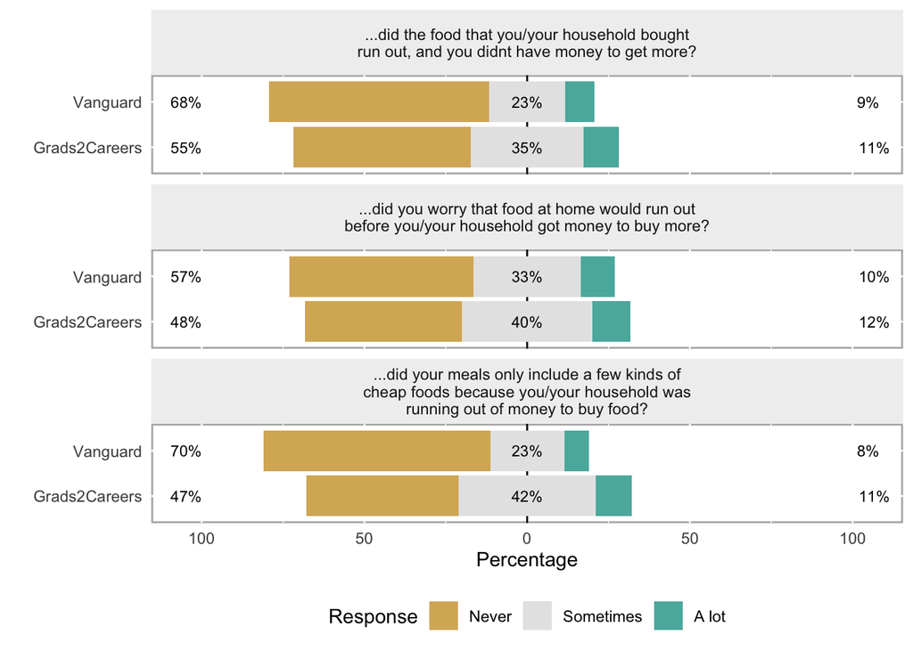

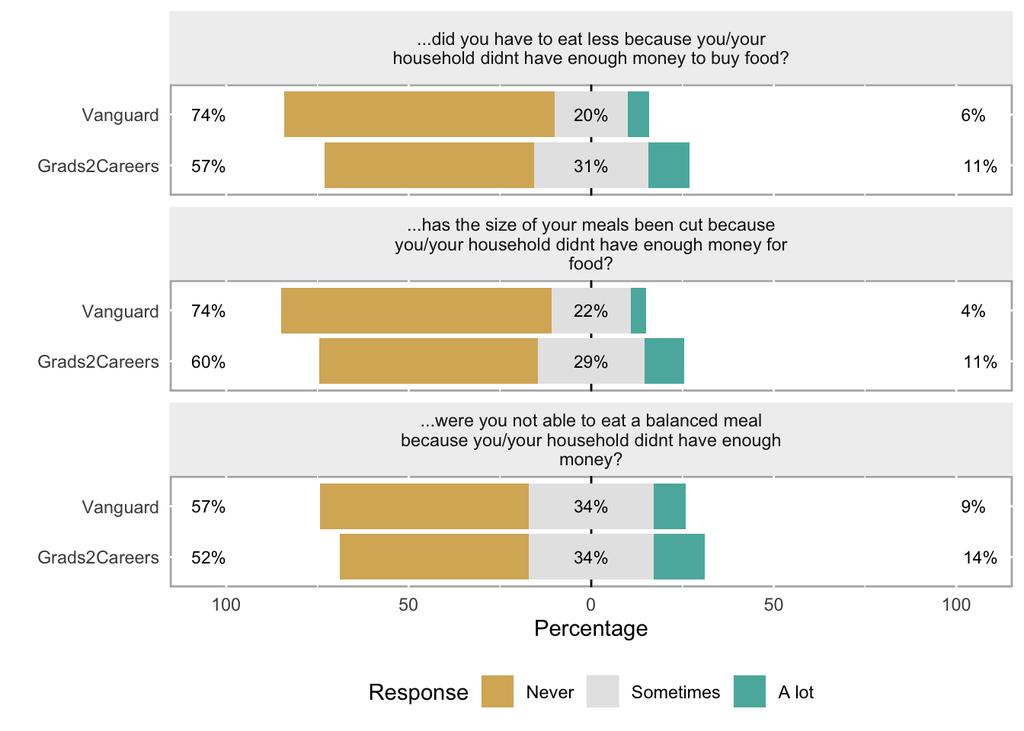

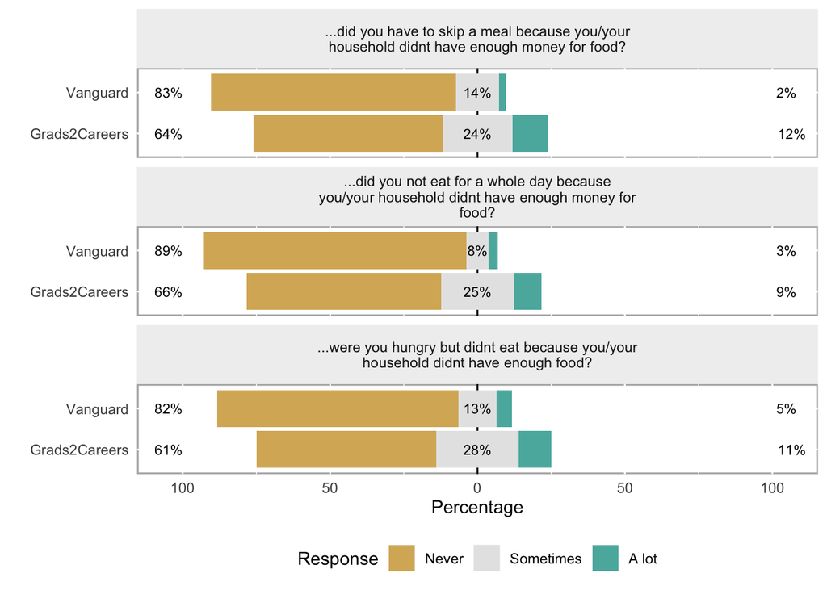

**Histogram of Food Security Scores (total of 9 variables, range:0-18): Vanguard vs. G2C**

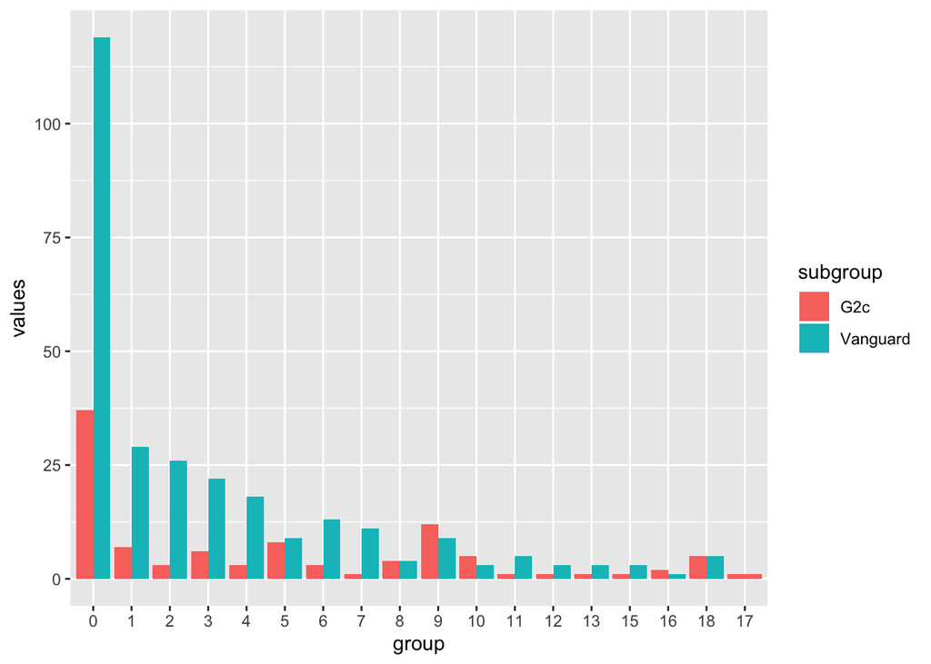

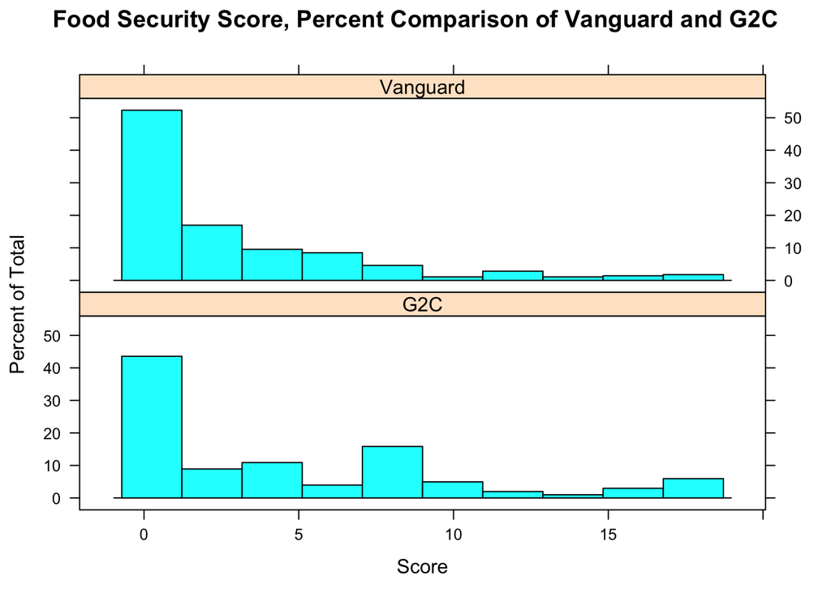

```
##
##  Wilcoxon rank sum test with continuity correction
##
## data:  food_total_merged$food_total_no_refused by food_total_merged$study
## W = 16710, p-value = 0.008864
## alternative hypothesis: true location shift is not equal to 0
```

```
##
##  Welch Two Sample t-test
##
## data:  food_total_merged$food_total_no_refused by food_total_merged$study
## t = 3.1362, df = 142.85, p-value = 0.002079
## alternative hypothesis: true difference in means is not equal to 0
## 95 percent confidence interval:
##  0.6850247 3.0207445
## sample estimates:
##      mean in group G2C mean in group Vanguard
##               4.831683               2.978799
```

Food Security Score comparison

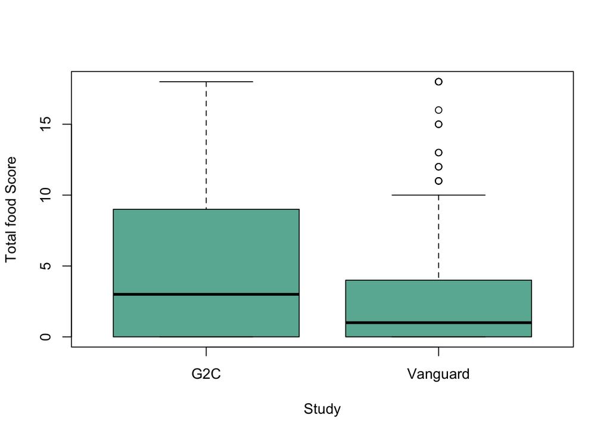